# Prediction From Exercise Data

scs

23/4/2020

## Background

(As given in the assignment for the course of practical machine learning)

Using devices such as Jawbone Up, Nike FuelBand, and Fitbit it is now possible to collect a large amount of data about personal activity relatively inexpensively. These type of devices are part of the quantified self movement – a group of enthusiasts who take measurements about themselves regularly to improve their health, to find patterns in their behavior, or because they are tech geeks. One thing that people regularly do is quantify how much of a particular activity they do, but they rarely quantify how well they do it. . More information is available from the website here: http://web.archive.org/web/20161224072740/http:/groupware.les.inf.puc-rio.br/har (see the section on the Weight Lifting Exercise Dataset).

## Goal of the project

The goal of this project is to use the data from accelerometers on the belt, forearm, arm, and dumbell of 6 participants and to predict the manner in which they did the exercise.They were asked to perform barbell lifts correctly and incorrectly in 5 different ways. The “classe” variable in the training set shows how the participants performed different tasks.

The report describes how the model is built and which model is the best one and why. The final prediction model is used to predict 20 different test cases.

## Data

The training data for this project are available here:

https://d396qusza40orc.cloudfront.net/predmachlearn/pml-training.csv

The test data are available here:

https://d396qusza40orc.cloudfront.net/predmachlearn/pml-testing.csv

Here in this project the data is downloaded to working directory and then read it in the R studio. It may be used directly by reading it from url.

```r
setwd("C:/Users/hp/desktop/coursera")
library(caret)
library(randomForest)
library(rattle)
library(forecast)
```

```r
library(rpart)
library(rpart.plot)
library(gbm)
```

# to bring data in R study

```r
data1<-read.csv("./pml-training.csv")
data2<-read.csv("./pml-testing.csv")
dim(data1)
```

```
## [1] 19622   160
```

```r
dim(data2)
```

```
## [1]  20 160
```

#DATA CLEANING

### To clean the pml-training data i.e data1 as per our problem:

-First of all data1(pml-training) is cleaned as per the requirement of our study. The vaiables from 1:7 are removed as they are not observations of the experiment and will not effect our prediction.

-Secondly the variables with near zero variance will be removed as these will not effect the prediction.

-lastly the variables with NA wil be removed as their significance for our prediction is negligible

```r
data1<-data1[,-(1:7)] # To remove first 7 variable
n_z_v<-nearZeroVar(data1) # To remove the variable which have near zero variance
data1<-data1[,-n_z_v]
na_var<-function(x)mean(is.na(x))# To remove the variables with NA
v_na<-sapply(data1,na_var)
data1<-data1[,-v_na==FALSE]
dim(data1)
```

```
## [1] 19622    53
```

### To clean the pml-testing data i.e data2 as per our problem:

-First of all data2(pml-testing) is cleaned as per the requirement of our study. The vaiables from 1:7 are removed as they are not observation of the experiment.

-Secondly the variables with near zero variance will be removed as these will not effect the prediction.

-lastly the variables with NA wil be removed as their significance for our prediction is negligible

```r
data2<-data2[,-(1:7)] # To remove first 7 variable
n_z_v1<-nearZeroVar(data2) # To remove the variable which have near zero variance
data2<-data2[,-n_z_v1]
na_var<-function(x)mean(is.na(x))# To remove the variables with NA
v_na<-sapply(data1,na_var)
data2<-data2[,-v_na==FALSE]
dim(data2)
```

```
## [1] 20 53
```

# To create data partition of data1 for training data and testing data

```r
inTrain<-createDataPartition(data1$classe,p=.7,list=FALSE)
data_train<-data1[inTrain,]
data_test<-data1[-inTrain,]
dim(data_train)
```

```
## [1] 13737    53
```

```r
dim(data_test)
```

```
## [1] 5885   53
```

# To fit the prediction model for different machine learning algorithms

### Linear Discriminant analysis

```r
library(lda)
fit_lda<-train(classe~.,data_train,method="lda")
pred_lda<-predict(fit_lda,newdata = data_test)
cm_lda<-confusionMatrix(pred_lda,data_test$classe)
cm_lda
```

```
## Confusion Matrix and Statistics
##
##           Reference
## Prediction    A    B    C    D    E
##          A 1378  163  104   55   26
##          B   37  723   82   30  191
##          C  130  150  693  108  106
##          D  124   51  120  736  105
##          E    5   52   27   35  654
##
## Overall Statistics
##
##                Accuracy : 0.711
##                  95% CI : (0.6992, 0.7225)
##     No Information Rate : 0.2845
##     P-Value [Acc > NIR] : < 2.2e-16
##
##                   Kappa : 0.6344
##
##  Mcnemar's Test P-Value : < 2.2e-16
##
## Statistics by Class:
##
##                      Class: A Class: B Class: C Class: D Class: E
## Sensitivity            0.8232   0.6348   0.6754   0.7635   0.6044
## Specificity            0.9174   0.9284   0.8983   0.9187   0.9752
## Pos Pred Value         0.7984   0.6802   0.5838   0.6479   0.8461
## Neg Pred Value         0.9288   0.9137   0.9291   0.9520   0.9163
## Prevalence             0.2845   0.1935   0.1743   0.1638   0.1839
## Detection Rate         0.2342   0.1229   0.1178   0.1251   0.1111
## Detection Prevalence   0.2933   0.1806   0.2017   0.1930   0.1314
## Balanced Accuracy      0.8703   0.7816   0.7869   0.8411   0.7898
```

### Decision Tree algrithm

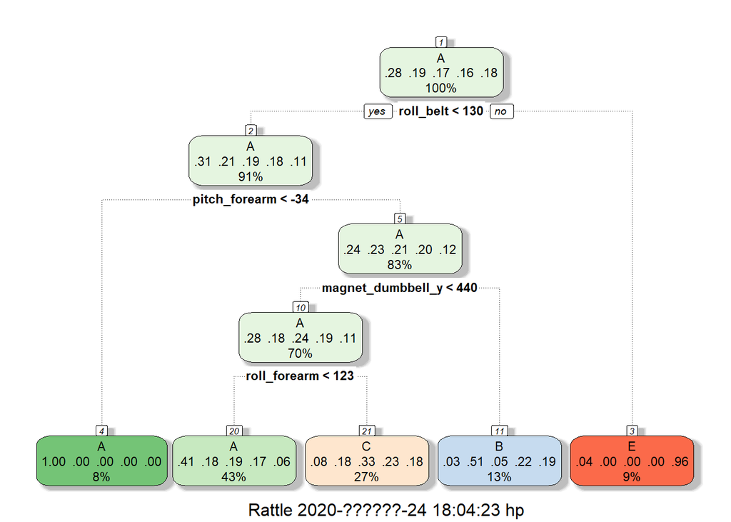

```r
fit_dt<-train(classe~.,data_train,method="rpart") # Decision tree
fancyRpartPlot(fit_dt$finalModel)
```

```r
# prediction
pred_dt<-predict(fit_dt,newdata = data_test)
cm_dt<-confusionMatrix(pred_dt,data_test$classe)
cm_dt
```

```
## Confusion Matrix and Statistics
##
##           Reference
## Prediction    A    B    C    D    E
##          A 1516  485  475  426  154
##          B   21  375   28  176  134
##          C  112  279  523  362  269
##          D    0    0    0    0    0
##          E   25    0    0    0  525
##
## Overall Statistics
##
##                Accuracy : 0.4994
##                  95% CI : (0.4865, 0.5123)
##     No Information Rate : 0.2845
##     P-Value [Acc > NIR] : < 2.2e-16
##
##                   Kappa : 0.3458
##
##  Mcnemar's Test P-Value : NA
##
## Statistics by Class:
##
##                      Class: A Class: B Class: C Class: D Class: E
## Sensitivity            0.9056  0.32924  0.50975   0.0000  0.48521
## Specificity            0.6343  0.92436  0.78967   1.0000  0.99479
## Pos Pred Value         0.4961  0.51090  0.33851      NaN  0.95455
## Neg Pred Value         0.9441  0.85168  0.88410   0.8362  0.89560
## Prevalence             0.2845  0.19354  0.17434   0.1638  0.18386
## Detection Rate         0.2576  0.06372  0.08887   0.0000  0.08921
## Detection Prevalence   0.5193  0.12472  0.26253   0.0000  0.09346
## Balanced Accuracy      0.7700  0.62680  0.64971   0.5000  0.74000
```

### Random Forest

```r
fit_rf<-train(classe~.,data_train,method="rf",ntree=100)
fit_rf
```

```
## Random Forest
##
## 13737 samples
##    52 predictor
##     5 classes: 'A', 'B', 'C', 'D', 'E'
##
## No pre-processing
## Resampling: Bootstrapped (25 reps)
## Summary of sample sizes: 13737, 13737, 13737, 13737, 13737, 13737, ...
## Resampling results across tuning parameters:
##
##   mtry  Accuracy   Kappa
##    2    0.9864107  0.9828039
##   27    0.9877985  0.9845603
##   52    0.9777634  0.9718615
##
## Accuracy was used to select the optimal model using the largest value.
## The final value used for the model was mtry = 27.
```

```r
pred_rf<-predict(fit_rf,newdata=data_test)
cm_rf<-confusionMatrix(pred_rf,data_test$classe)
cm_rf
```

```
## Confusion Matrix and Statistics
##
##           Reference
## Prediction    A    B    C    D    E
##          A 1671    4    0    1    0
##          B    3 1133    2    0    0
##          C    0    2 1021    8    4
##          D    0    0    3  955    3
##          E    0    0    0    0 1075
##
## Overall Statistics
##
##                Accuracy : 0.9949
##                  95% CI : (0.9927, 0.9966)
##     No Information Rate : 0.2845
##     P-Value [Acc > NIR] : < 2.2e-16
##
##                   Kappa : 0.9936
##
##  Mcnemar's Test P-Value : NA
##
## Statistics by Class:
##
##                      Class: A Class: B Class: C Class: D Class: E
## Sensitivity            0.9982   0.9947   0.9951   0.9907   0.9935
## Specificity            0.9988   0.9989   0.9971   0.9988   1.0000
## Pos Pred Value         0.9970   0.9956   0.9865   0.9938   1.0000
## Neg Pred Value         0.9993   0.9987   0.9990   0.9982   0.9985
## Prevalence             0.2845   0.1935   0.1743   0.1638   0.1839
## Detection Rate         0.2839   0.1925   0.1735   0.1623   0.1827
## Detection Prevalence   0.2848   0.1934   0.1759   0.1633   0.1827
## Balanced Accuracy      0.9985   0.9968   0.9961   0.9947   0.9968
```

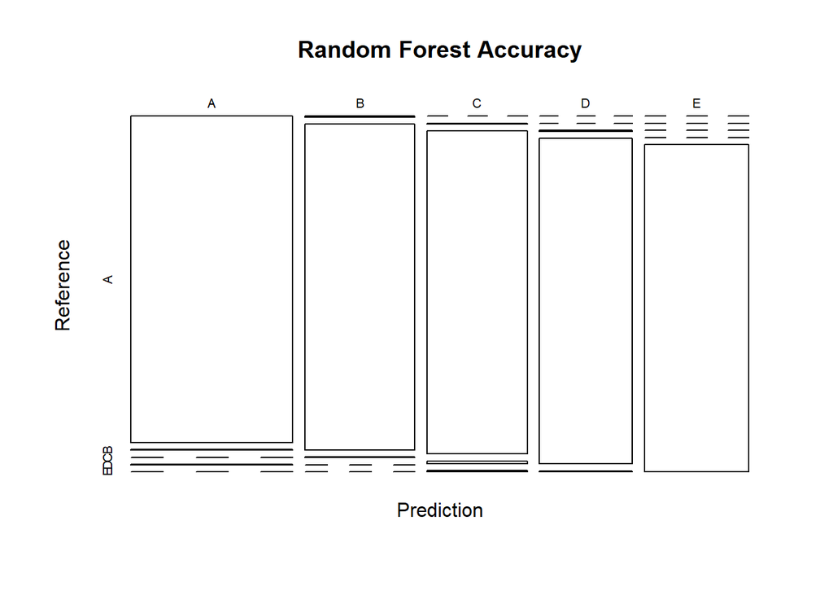

```r
plot(cm_rf$table,col=cm_rf$byClass,main="Random Forest Accuracy")
```

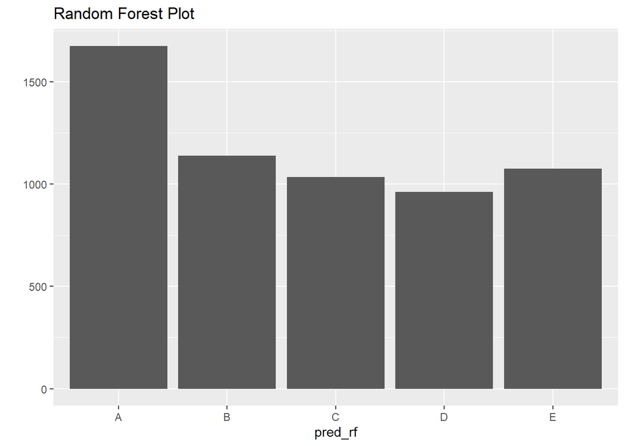

```r
qplot(pred_rf,data=data_test,main="Random Forest Plot")
```

# Gradient boosting model and prediction

```r
fit_gbm<-train(classe~.,data=data_train,method="gbm",verbose=FALSE)
fit_gbm
```

```
## Stochastic Gradient Boosting
##
## 13737 samples
##    52 predictor
##     5 classes: 'A', 'B', 'C', 'D', 'E'
##
## No pre-processing
## Resampling: Bootstrapped (25 reps)
## Summary of sample sizes: 13737, 13737, 13737, 13737, 13737, 13737, ...
## Resampling results across tuning parameters:
##
##   interaction.depth  n.trees  Accuracy   Kappa
##   1                   50      0.7481934  0.6807288
##   1                  100      0.8174430  0.7688733
##   1                  150      0.8502794  0.8104699
##   2                   50      0.8525252  0.8130667
##   2                  100      0.9035291  0.8778698
##   2                  150      0.9275049  0.9082299
##   3                   50      0.8931738  0.8647022
##   3                  100      0.9377888  0.9212481
##   3                  150      0.9559548  0.9442534
##
## Tuning parameter 'shrinkage' was held constant at a value of 0.1
##
## Tuning parameter 'n.minobsinnode' was held constant at a value of 10
## Accuracy was used to select the optimal model using the largest value.
## The final values used for the model were n.trees = 150, interaction.depth =
##  3, shrinkage = 0.1 and n.minobsinnode = 10.
```

```r
pred_gbm<-predict(fit_gbm,newdata=data_test)
cm_gbm<-confusionMatrix(pred_gbm,data_test$classe)
cm_gbm
```

```
## Confusion Matrix and Statistics
##
##           Reference
## Prediction    A    B    C    D    E
##          A 1642   18    0    1    1
##          B   24 1084   25    5   18
##          C    7   36  991   22   11
##          D    1    0   10  927   11
##          E    0    1    0    9 1041
##
## Overall Statistics
##
##                Accuracy : 0.966
##                  95% CI : (0.9611, 0.9705)
##     No Information Rate : 0.2845
##     P-Value [Acc > NIR] : < 2.2e-16
##
##                   Kappa : 0.957
##
##  Mcnemar's Test P-Value : 1.048e-06
##
## Statistics by Class:
##
##                      Class: A Class: B Class: C Class: D Class: E
## Sensitivity            0.9809   0.9517   0.9659   0.9616   0.9621
## Specificity            0.9953   0.9848   0.9844   0.9955   0.9979
## Pos Pred Value         0.9880   0.9377   0.9288   0.9768   0.9905
## Neg Pred Value         0.9924   0.9884   0.9927   0.9925   0.9915
## Prevalence             0.2845   0.1935   0.1743   0.1638   0.1839
## Detection Rate         0.2790   0.1842   0.1684   0.1575   0.1769
## Detection Prevalence   0.2824   0.1964   0.1813   0.1613   0.1786
## Balanced Accuracy      0.9881   0.9683   0.9751   0.9786   0.9800
```

# Most suitable method

-The accuracy of Decision Tree method is .49 which is not acceptable.So the method is not suitable for the present study.

-The accuracy of random forest method is .99 so the method of random forest is most suitable one. #### Thus the most suitable method is random forest.

# To use the final prediction method (random forest) for data2 (pml-testing)

```r
T_pred_rf<-predict(fit_rf,newdata=data2)
T_pred_rf
```

```
##  [1] B A B A A E D B A A B C B A E E A B B B
## Levels: A B C D E
```